# Statistical Inference Course Project - Part 2

Prepared by Byron Stuart

## Overview

Basic inferential data analysis, analyze the ToothGrowth data in the R datasets package.

### 1. Load the ToothGrowth data and perform some basic exploratory data analyses

```r
data(ToothGrowth)
head(ToothGrowth)
```

```
##    len supp dose
## 1  4.2   VC  0.5
## 2 11.5   VC  0.5
## 3  7.3   VC  0.5
## 4  5.8   VC  0.5
## 5  6.4   VC  0.5
## 6 10.0   VC  0.5
```

```r
str(ToothGrowth)
```

```
## 'data.frame':    60 obs. of  3 variables:
##  $ len : num  4.2 11.5 7.3 5.8 6.4 10 11.2 11.2 5.2 7 ...
##  $ supp: Factor w/ 2 levels "OJ","VC": 2 2 2 2 2 2 2 2 2 2 ...
##  $ dose: num  0.5 0.5 0.5 0.5 0.5 0.5 0.5 0.5 0.5 0.5 ...
```

```r
# Convert to factor for boxplot
ToothGrowth$dose <- as.factor(ToothGrowth$dose)
```

### 2. Provide a basic summary of the data.

```r
summary(ToothGrowth)
```

```
##       len        supp     dose
##  Min.   : 4.20   OJ:30   0.5:20
##  1st Qu.:13.07   VC:30   1  :20
##  Median :19.25           2  :20
##  Mean   :18.81
##  3rd Qu.:25.27
##  Max.   :33.90
```

```r
library(ggplot2)
```

#### Further Analysis

```r
# t test impact on length by supplement
t.test(len ~ supp, ToothGrowth)
```

```
##
##  Welch Two Sample t-test
##
## data:  len by supp
## t = 1.9153, df = 55.309, p-value = 0.06063
## alternative hypothesis: true difference in means is not equal to 0
## 95 percent confidence interval:
##  -0.1710156  7.5710156
## sample estimates:
## mean in group OJ mean in group VC
##         20.66333         16.96333
```

#### The p-value 0.06 is greater than an alpha of 0.05 (95% confidence interval) and the difference in the means spans 0 so we cannot say that one supplement is better than another

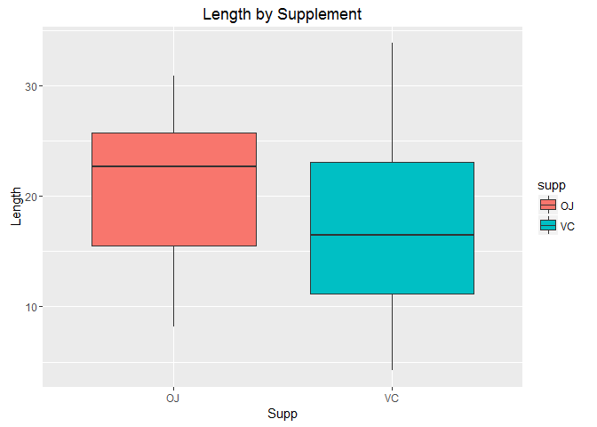

```r
graph <- ggplot(ToothGrowth, aes(x=supp, y=len)) +
    geom_boxplot(aes(fill=supp)) +
    ylab("Length")  +
    xlab("Supp") +
    ggtitle("Length by Supplement")
graph
```

#### Based on averages alone OJ has longer lengths than VC but more investigation is required

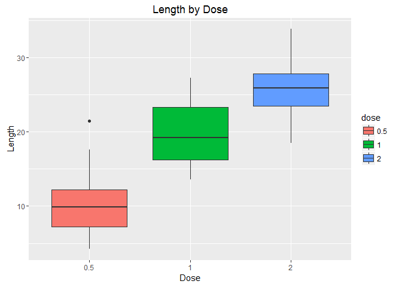

```r
graph <- ggplot(ToothGrowth, aes(x=dose, y=len)) +
    geom_boxplot(aes(fill=dose)) +
    ylab("Length")  +
    xlab("Dose") +
    ggtitle("Length by Dose")
graph
```

#### Considering both supplements the higher the dose the higher the average length is

### 3. Use confidence intervals and/or hypothesis tests to compare tooth growth by supp and dose.

#### 3a. Perform a two sample t test of OJ and VC

```r
t.test(len ~ supp, data=ToothGrowth, paired=FALSE, var.equal=FALSE)
```

```
##
##  Welch Two Sample t-test
##
## data:  len by supp
## t = 1.9153, df = 55.309, p-value = 0.06063
## alternative hypothesis: true difference in means is not equal to 0
## 95 percent confidence interval:
##  -0.1710156  7.5710156
## sample estimates:
## mean in group OJ mean in group VC
##         20.66333         16.96333
```

#### The p-value 0.06 is greater than an alpha of 0.05 (95% confidence interval) and the difference in the means spans 0 hence the Null Hypothesis is “Failed to Reject”, that is we cannot see a significant difference between supplements.

#### 3b. Perform a two sample t test at each dosage for OJ and VC (3 test results follow)

```r
t.test(len ~ supp, ToothGrowth[ToothGrowth$dose == .5, ])
```

```
##
##  Welch Two Sample t-test
##
## data:  len by supp
## t = 3.1697, df = 14.969, p-value = 0.006359
## alternative hypothesis: true difference in means is not equal to 0
## 95 percent confidence interval:
##  1.719057 8.780943
## sample estimates:
## mean in group OJ mean in group VC
##            13.23             7.98
```

```r
t.test(len ~ supp, ToothGrowth[ToothGrowth$dose == 1, ])
```

```
##
##  Welch Two Sample t-test
##
## data:  len by supp
## t = 4.0328, df = 15.358, p-value = 0.001038
## alternative hypothesis: true difference in means is not equal to 0
## 95 percent confidence interval:
##  2.802148 9.057852
## sample estimates:
## mean in group OJ mean in group VC
##            22.70            16.77
```

#### At doses of 0.5 and 1 the p-value is less than an alpha of 0.05 (95% confidence interval) and the difference in the means does not span 0 hence the Null Hypothesis is “Rejected”, that is we can see a significant difference between supplements.

```r
t.test(len ~ supp, ToothGrowth[ToothGrowth$dose == 2, ])
```

```
##
##  Welch Two Sample t-test
##
## data:  len by supp
## t = -0.046136, df = 14.04, p-value = 0.9639
## alternative hypothesis: true difference in means is not equal to 0
## 95 percent confidence interval:
##  -3.79807  3.63807
## sample estimates:
## mean in group OJ mean in group VC
##            26.06            26.14
```

#### At a dose of 2 the p-value is greater than an alpha of 0.05 (95% confidence interval) and the difference in the means spans 0 hence the Null Hypothesis is “Failed to Reject”, that is we cannot see a significant difference between supplements.

#### 3c. Perform separate two sample t test comparing doses of: 0.5 and 1; 1 and 2.

```r
t.test(ToothGrowth$len[ToothGrowth$dose==0.5], ToothGrowth$len[ToothGrowth$dose==1], paired=FALSE, var.equal=FALSE)
```

```
##
##  Welch Two Sample t-test
##
## data:  ToothGrowth$len[ToothGrowth$dose == 0.5] and ToothGrowth$len[ToothGrowth$dose == 1]
## t = -6.4766, df = 37.986, p-value = 1.268e-07
## alternative hypothesis: true difference in means is not equal to 0
## 95 percent confidence interval:
##  -11.983781  -6.276219
## sample estimates:
## mean of x mean of y
##    10.605    19.735
```

```r
t.test(ToothGrowth$len[ToothGrowth$dose==1], ToothGrowth$len[ToothGrowth$dose==2], paired=FALSE, var.equal=FALSE)
```

```
##
##  Welch Two Sample t-test
##
## data:  ToothGrowth$len[ToothGrowth$dose == 1] and ToothGrowth$len[ToothGrowth$dose == 2]
## t = -4.9005, df = 37.101, p-value = 1.906e-05
## alternative hypothesis: true difference in means is not equal to 0
## 95 percent confidence interval:
##  -8.996481 -3.733519
## sample estimates:
## mean of x mean of y
##    19.735    26.100
```

#### For each of the 2 tests above the p-value is less than an alpha of 0.05 (95% confidence interval) and the difference in the means does not span 0. Hence the Null Hypothesis is “Rejected” in both cases showing there is a significant difference in length for higher doses of supplements. There is no need to test the difference between 0.5 and 2 given the above results.

### 4. State your conclusions and the assumptions needed for your conclusions.

#### Assumptions

1. The data follows a T distribution
2. The Data is derived from samples that are representative of the population
3. Variances between populations are different